# 4. Time Series Features.RMD

Russ Conte

10/3/2021

The `feasts` package includes functions for computing FEatures And Statistics from Time Series (hence the name).

We can compute many different features on many different time series, and use them to explore the properties of the series. In this chapter we will look at some features that have been found useful in time series exploration, and how they can be used to uncover interesting information about your data. We will use Australian quarterly tourism as a running example.

## 4.1 Some simple statistics

Any numerical summary computed from a time series is a feature of that time series — the mean, minimum or maximum, for example. These can be computed using the features() function. For example, let’s compute the means of all the series in the Australian tourism data.

```r
library(fpp3)
library(tidyverse)
tourism %>%
  features(Trips, list(mean = mean)) %>%
  arrange(desc(mean))
```

```
## # A tibble: 304 × 4
##    Region          State           Purpose   mean
##    <chr>           <chr>           <chr>    <dbl>
##  1 Sydney          New South Wales Visiting  747.
##  2 Melbourne       Victoria        Visiting  619.
##  3 Sydney          New South Wales Business  602.
##  4 North Coast NSW New South Wales Holiday   588.
##  5 Sydney          New South Wales Holiday   550.
##  6 Gold Coast      Queensland      Holiday   528.
##  7 Melbourne       Victoria        Holiday   507.
##  8 South Coast     New South Wales Holiday   495.
##  9 Brisbane        Queensland      Visiting  493.
## 10 Melbourne       Victoria        Business  478.
## # … with 294 more rows
```

Rather than compute one feature at a time, it is convenient to compute many features at once. A common short summary of a data set is to compute five summary statistics: the minimum, first quartile, median, third quartile and maximum. These divide the data into four equal-size sections, each containing 25% of the data. The quantile() function can be used to compute them.

```r
tourism %>% features(Trips, quantile)
```

```
## # A tibble: 304 × 8
##    Region         State             Purpose    `0%`  `25%`   `50%`  `75%` `100%`
##    <chr>          <chr>             <chr>     <dbl>  <dbl>   <dbl>  <dbl>  <dbl>
##  1 Adelaide       South Australia   Busine…  68.7   134.   153.    177.   242.
##  2 Adelaide       South Australia   Holiday 108.    135.   154.    172.   224.
##  3 Adelaide       South Australia   Other    25.9    43.9   53.8    62.5  107.
##  4 Adelaide       South Australia   Visiti… 137.    179.   206.    229.   270.
##  5 Adelaide Hills South Australia   Busine…   0       0      1.26    3.92  28.6
##  6 Adelaide Hills South Australia   Holiday   0       5.77   8.52   14.1   35.8
##  7 Adelaide Hills South Australia   Other     0       0      0.908   2.09   8.95
##  8 Adelaide Hills South Australia   Visiti…   0.778   8.91  12.2    16.8   81.1
##  9 Alice Springs  Northern Territo… Busine…   1.01    9.13  13.3    18.5   34.1
## 10 Alice Springs  Northern Territo… Holiday   2.81   16.9   31.5    44.8   76.5
## # … with 294 more rows
```

## 4.2 Autocorrelation (ACF) Features

We discuss differencing of time series in more detail in Section 9.1.

The `feat_acf()` function computes a selection of the autocorrelations discussed here. It will return six or seven features:

• the first autocorrelation coefficient from the original data; • the sum of squares of the first ten autocorrelation coefficients from the original data; • the first autocorrelation coefficient from the differenced data; • the sum of squares of the first ten autocorrelation coefficients from the differenced data; • the first autocorrelation coefficient from the twice differenced data; • the sum of squares of the first ten autocorrelation coefficients from the twice differenced data; • For seasonal data, the autocorrelation coefficient at the first seasonal lag is also returned.

For example:

```r
tourism %>% filter(Purpose == "Business") %>% features(Trips, feat_acf)
```

```
## # A tibble: 76 × 10
##    Region      State    Purpose    acf1  acf10 diff1_acf1 diff1_acf10 diff2_acf1
##    <chr>       <chr>    <chr>     <dbl>  <dbl>      <dbl>       <dbl>      <dbl>
##  1 Adelaide    South A… Busine…  0.0333 0.131      -0.520       0.463     -0.676
##  2 Adelaide H… South A… Busine…  0.0709 0.134      -0.580       0.415     -0.750
##  3 Alice Spri… Norther… Busine…  0.217  0.367      -0.500       0.381     -0.658
##  4 Australia'… Western… Busine…  0.245  0.864      -0.618       0.820     -0.710
##  5 Australia'… Western… Busine…  0.517  1.72       -0.546       0.420     -0.632
##  6 Australia'… Western… Busine…  0.840  4.37       -0.430       0.408     -0.608
##  7 Australia'… Western… Busine…  0.395  0.672      -0.301       0.350     -0.488
##  8 Ballarat    Victoria Busine… -0.115  0.109      -0.531       0.452     -0.659
##  9 Barkly      Norther… Busine…  0.160  0.241      -0.606       1.01      -0.804
## 10 Barossa     South A… Busine…  0.139  0.0748     -0.423       0.284     -0.636
## # … with 66 more rows, and 2 more variables: diff2_acf10 <dbl>,
## #   season_acf1 <dbl>
```

## 4.3 STL Features

A time series decomposition can be used to measure the strength of trend and seasonality in a time series. Recall that the decomposition is written as:

$$y_t = T_t + S_t + R_t$$

where
$$T_t$$
is the smoothed trend component,
$$S_t$$
is the seasonal component and
$$R_t$$
is a remainder component. For strongly trended data, the seasonally adjusted data should have much more variation than the remainder component.

We define the strength of trend as:

$$F_T = max \left(0, 1 -\frac{Var(R_t)}{Var(T_t + R_t)}\right)$$

Strength of seasonality is similar:

$$F_S = max \left(0, 1 -\frac{Var(R_t)}{Var(S_t + R_t)}\right)$$

A series with seasonal strength
$$F_S$$
close to 0 exhibits almost no seasonality, while a series with strong seasonality will have
$$F_s$$
close to 1 vbecayse
$$Var(R_t)$$
will be much smaller than
$$Var(S_t + R_t)$$

```r
tourism %>%
  features(Trips, feat_stl)
```

```
## # A tibble: 304 × 12
##    Region         State Purpose trend_strength seasonal_streng… seasonal_peak_y…
##    <chr>          <chr> <chr>            <dbl>            <dbl>            <dbl>
##  1 Adelaide       Sout… Busine…          0.464            0.407                3
##  2 Adelaide       Sout… Holiday          0.554            0.619                1
##  3 Adelaide       Sout… Other            0.746            0.202                2
##  4 Adelaide       Sout… Visiti…          0.435            0.452                1
##  5 Adelaide Hills Sout… Busine…          0.464            0.179                3
##  6 Adelaide Hills Sout… Holiday          0.528            0.296                2
##  7 Adelaide Hills Sout… Other            0.593            0.404                2
##  8 Adelaide Hills Sout… Visiti…          0.488            0.254                0
##  9 Alice Springs  Nort… Busine…          0.534            0.251                0
## 10 Alice Springs  Nort… Holiday          0.381            0.832                3
## # … with 294 more rows, and 6 more variables: seasonal_trough_year <dbl>,
## #   spikiness <dbl>, linearity <dbl>, curvature <dbl>, stl_e_acf1 <dbl>,
## #   stl_e_acf10 <dbl>
```

**We can then use these features in plots to identify what type of series are heavily trended and what are most seasonal.**

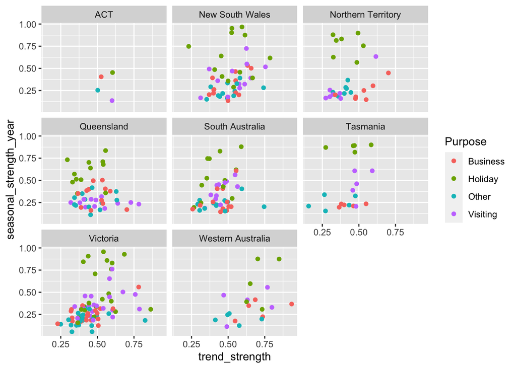

```r
tourism %>%
  features(Trips, feat_stl) %>%
  ggplot(aes(x = trend_strength, y = seasonal_strength_year, col = Purpose)) +
  geom_point() +
  facet_wrap(vars(State))
```

Clearly, holiday series are most seasonal which is unsurprising. The strongest trends tend to be in Western Australia and Victoria. The most seasonal series can also be easily identified and plotted.

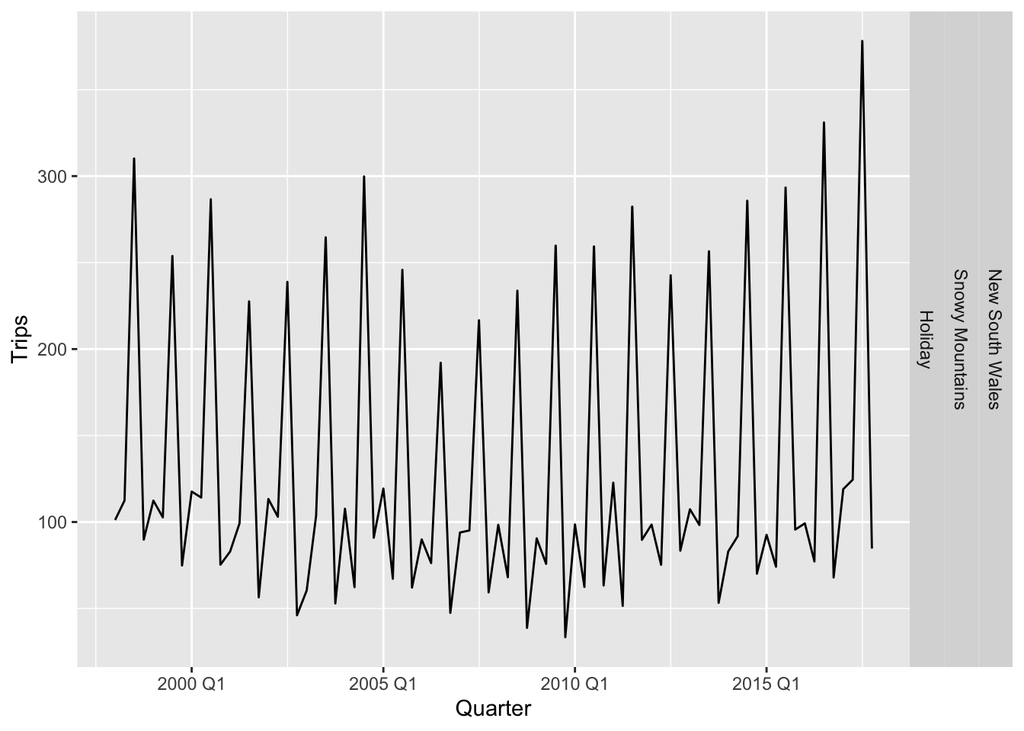

```r
tourism %>%
  features(Trips, feat_stl) %>%
  filter(seasonal_strength_year == max(seasonal_strength_year)) %>%
  left_join(tourism, by = c("State", "Region", "Purpose")) %>%
  ggplot(aes(x = Quarter, y = Trips)) +
  geom_line() +
  facet_grid(vars(State, Region, Purpose))
```

This shows holiday trips to the most popular ski region of Australia.

The `feat_stl()` function returns several more features other than those discussed above.

• `seasonal_peak_year` indicates the timing of the peaks — which month or quarter contains the largest seasonal component. This tells us something about the nature of the seasonality. In the Australian tourism data, if Quarter 3 is the peak seasonal period, then people are travelling to the region in winter, whereas a peak in Quarter 1 suggests that the region is more popular in summer.
• `seasonal_trough_year` indicates the timing of the troughs — which month or quarter contains the smallest seasonal component.
• `spikiness` measures the prevalence of spikes in the remainder component
$$R_t$$
of the of the STL decomposition. It is the variance of the leave-one-out variances of
$$R_t$$
• linearity measures the linearity of the trend component of the STL decomposition. It is based on the coefficient of a linear regression applied to the trend component.
• curvature measures the curvature of the trend component of the STL decomposition. It is based on the coefficient from an orthogonal quadratic regression applied to the trend component.
• `stl_e_acf1` is the first autocorrelation coefficient of the remainder series.
• `stl_e_acf10` is the sum of squares of the first ten autocorrelation coefficients of the remainder series.

## 4.4 List of other features

The remaining features in the feasts package, not previously discussed, are listed here for reference. The details of some of them are discussed later in the book.  
• `coef_hurst` will calculate the Hurst coefficient of a time series which is a measure of “long memory.” A series with long memory will have significant autocorrelations for many lags.  
• `feat_spectral` will compute the (Shannon) spectral entropy of a time series, which is a measure of how easy the series is to forecast. A series which has strong trend and seasonality (and so is easy to forecast) will have entropy close to 0. A series that is very noisy (and so is difficult to forecast) will have entropy close to 1.  
• `box_pierce` gives the Box-Pierce statistic for testing if a time series is white noise, and the corresponding p-value. This test is discussed in Section 5.4.  
• `ljung_box` gives the Ljung-Box statistic for testing if a time series is white noise, and the corresponding p-value. This test is discussed in Section 5.4.  
The k-th partial autocorrelation measures the relationship between observations k periods apart after removing the effects of observations between them. So the first partial autocorrelation (k=1) is identical to the first autocorrelation, because there is nothing between consecutive observations to remove. Partial autocorrelations are discussed in Section 9.5. The `feat_pacf` function contains several features involving partial autocorrelations including the sum of squares of the first five partial autocorrelations for the original series, the first-differenced series and the second-differenced series. For seasonal data, it also includes the partial autocorrelation at the first seasonal lag.  
• `unitroot_kpss` gives the Kwiatkowski-Phillips-Schmidt-Shin (KPSS) statistic for testing if a series is stationary, and the corresponding p-value. This test is discussed in Section 9.1.  
• `unitroot_pp` gives the Phillips-Perron statistic for testing if a series is non-stationary, and the corresponding p-value.  
• `unitroot_ndiffs` gives the number of differences required to lead to a stationary series based on the KPSS test. This is discussed in Section 9.1 unitroot_nsdiffs gives the number of seasonal differences required to make a series stationary. This is discussed in Section 9.1.  
• `var_tiled_mean` gives the variances of the “tiled means” (i.e., the means of consecutive non-overlapping blocks of observations). The default tile length is either 10 (for non-seasonal data)  
or the length of the seasonal period. This is sometimes called the “stability” feature. • `var_tiled_var` gives the variances of the “tiled variances” (i.e., the variances of consecutive non-overlapping blocks of observations). This is sometimes called the “lumpiness” feature.  
• `shift_level_max` finds the largest mean shift between two consecutive sliding windows of the time series. This is useful for finding sudden jumps or drops in a time series.  
• `shift_level_index` gives the index at which the largest mean shift occurs.  
• `shift_var_max` finds the largest variance shift between two consecutive sliding windows of the time series. This is useful for finding sudden changes in the volatility of a time series.  
• `shift_var_index` gives the index at which the largest variance shift occurs.  
• `shift_kl_max` finds the largest distributional shift (based on the Kulback-Leibler divergence) between two consecutive sliding windows of the time series. This is useful for finding sudden changes in the distribution of a time series.  
• `shift_kl_index` gives the index at which the largest KL shift occurs.  
• `n_crossing_points` computes the number of times a time series crosses the median. longest_flat_spot computes the number of sections of the data where the series is relatively unchanging.  
stat_arch_lm returns the statistic based on the Lagrange Multiplier (LM) test of Engle (1982) for autoregressive conditional heteroscedasticity (ARCH).  
• `guerrero` computes the optimal λ value for a Box-Cox transformation using the Guerrero method (discussed in Section 3.1).

## 4.5 Exploring Austraian Tourism Data

All of the features included in the feasts package can be computed in one line like this:

```r
tourism_features <- tourism %>%
  features(Trips, feature_set(pkgs = "feasts"))
tourism_features
```

```
## # A tibble: 304 × 51
##    Region         State Purpose trend_strength seasonal_streng… seasonal_peak_y…
##    <chr>          <chr> <chr>            <dbl>            <dbl>            <dbl>
##  1 Adelaide       Sout… Busine…          0.464            0.407                3
##  2 Adelaide       Sout… Holiday          0.554            0.619                1
##  3 Adelaide       Sout… Other            0.746            0.202                2
##  4 Adelaide       Sout… Visiti…          0.435            0.452                1
##  5 Adelaide Hills Sout… Busine…          0.464            0.179                3
##  6 Adelaide Hills Sout… Holiday          0.528            0.296                2
##  7 Adelaide Hills Sout… Other            0.593            0.404                2
##  8 Adelaide Hills Sout… Visiti…          0.488            0.254                0
##  9 Alice Springs  Nort… Busine…          0.534            0.251                0
## 10 Alice Springs  Nort… Holiday          0.381            0.832                3
## # … with 294 more rows, and 45 more variables: seasonal_trough_year <dbl>,
## #   spikiness <dbl>, linearity <dbl>, curvature <dbl>, stl_e_acf1 <dbl>,
## #   stl_e_acf10 <dbl>, acf1 <dbl>, acf10 <dbl>, diff1_acf1 <dbl>,
## #   diff1_acf10 <dbl>, diff2_acf1 <dbl>, diff2_acf10 <dbl>, season_acf1 <dbl>,
## #   pacf5 <dbl>, diff1_pacf5 <dbl>, diff2_pacf5 <dbl>, season_pacf <dbl>,
## #   zero_run_mean <dbl>, nonzero_squared_cv <dbl>, zero_start_prop <dbl>,
## #   zero_end_prop <dbl>, lambda_guerrero <dbl>, kpss_stat <dbl>, …
```

This gives 48 features for every combination of the three key variables (Region, State and Purpose). We can treat this tibble like any data set and analyse it to find interesting observations or groups of observations.

We’ve already seen how we can plot one feature against another (Section 4.3). We can also do pairwise plots of groups of features. In Figure 4.3, for example, we show all features that involve seasonality, along with the `Purpose` variable.

```r
library(glue)
```

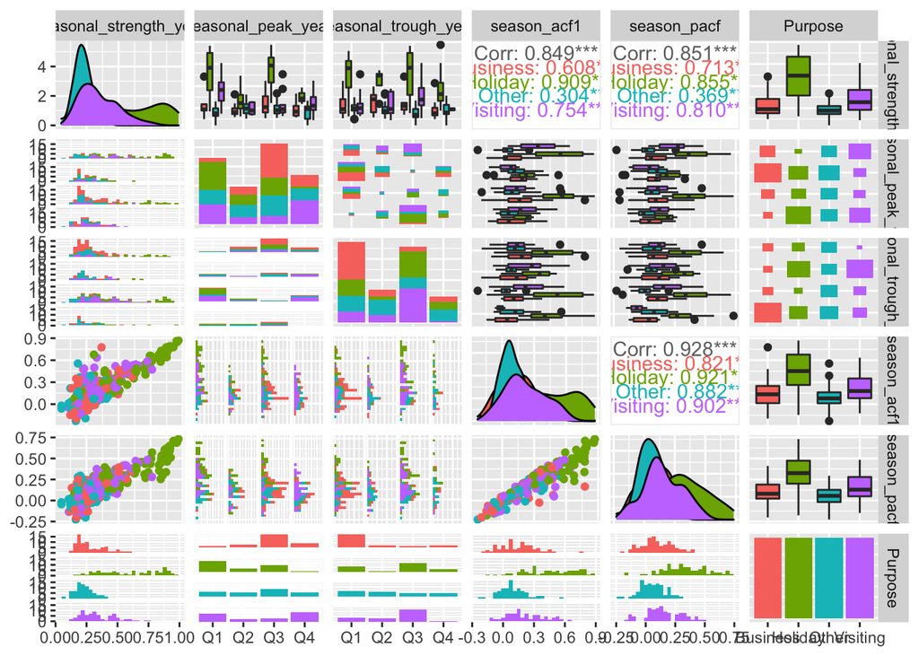

```r
tourism_features %>%
  select_at(vars(contains("season"), Purpose)) %>%
              mutate(
                seasonal_peak_year = seasonal_peak_year + 4*(seasonal_peak_year == 0),
                seasonal_trough_year = seasonal_trough_year + 4*(seasonal_trough_year == 0),
                seasonal_peak_year = glue("Q{seasonal_peak_year}"),
                seasonal_trough_year = glue("Q{seasonal_trough_year}"),
              ) %>%
  GGally::ggpairs(mapping = aes(colour = Purpose))
```

Here, the Purpose variable is mapped to colour. There is a lot of information in this figure, and we will highlight just a few things we can learn.

• The three numerical measures related to seasonality (`seasonal_strength_year`, `season_acf1` and `season_pacf`) are all positively correlated. • The bottom left panel and the top right panel both show that the most strongly seasonal series are related to holidays (as we saw previously). • The bar plots in the bottom row of the `seasonal_peak_year` and `seasonal_trough_year` columns show that seasonal peaks in Business travel occurs most often in Quarter 3, and least often in Quarter 1.

It is difficult to explore more than a handful of variables in this way. A useful way to handle many more variables is to use a dimension reduction technique such as principal components. This gives linear combinations of variables that explain the most variation in the original data. We can compute the principal components of the tourism features as follows.

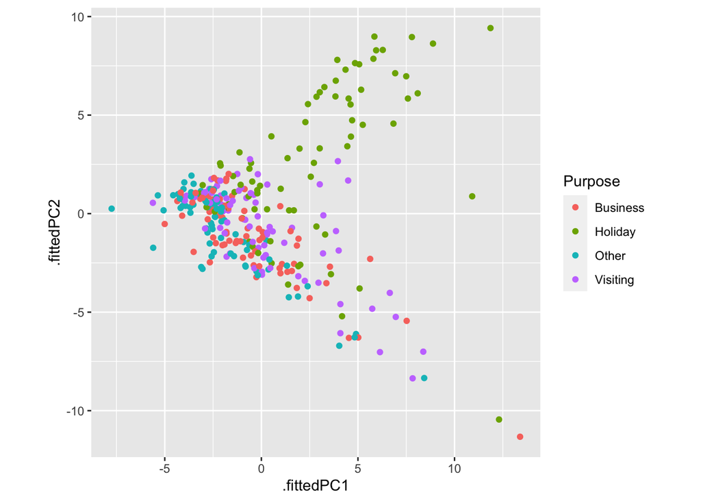

```r
library(broom)
pcs <- tourism_features %>%
  select(-State, -Region, -Purpose) %>%
  prcomp(scale = TRUE) %>%
  augment(tourism_features)
pcs %>%
  ggplot(aes(x = .fittedPC1, y = .fittedPC2, col = Purpose)) +
  geom_point() +
  theme(aspect.ratio = 1)
```

Each point on Figure 4.4 represents one series and its location on the plot is based on all 48 features. The first principal component (.fittedPC1) is the linear combination of the features which explains the most variation in the data. The second principal component (.fittedPC2) is the linear combination which explains the next most variation in the data, while being uncorrelated with the first principal component.

Figure 4.4 reveals a few things about the tourism data. First, the holiday series behave quite differently from the rest of the series. Almost all of the holiday series appear in the top half of the plot, while almost all of the remaining series appear in the bottom half of the plot. Clearly, the second principal component is distinguishing between holidays and other types of travel.

The plot also allows us to identify anomalous time series — series which have unusual feature combinations. These appear as points that are separate from the majority of series in Figure 4.4. There are four that stand out, and we can identify which series they correspond to as follows.

```r
outliers <- pcs %>%
  filter(.fittedPC1>10) %>%
  select(Region, State, Purpose, .fittedPC1, .fittedPC2)
outliers
```

```
## # A tibble: 4 × 5
##   Region                 State             Purpose  .fittedPC1 .fittedPC2
##   <chr>                  <chr>             <chr>         <dbl>      <dbl>
## 1 Australia's North West Western Australia Business       13.4    -11.3
## 2 Australia's South West Western Australia Holiday        10.9      0.880
## 3 Melbourne              Victoria          Holiday        12.3    -10.4
## 4 South Coast            New South Wales   Holiday        11.9      9.42
```

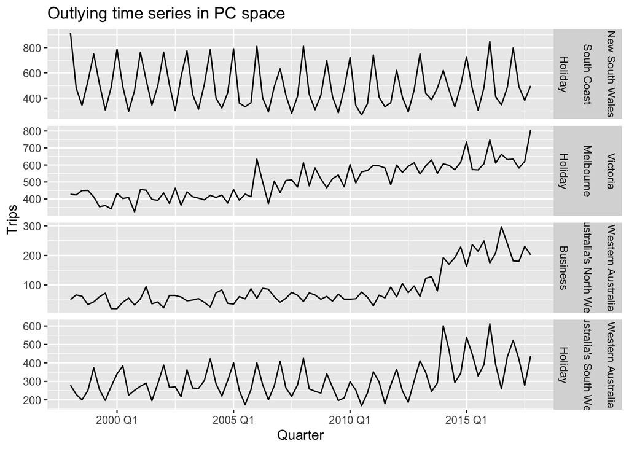

```r
outliers %>%
  left_join(tourism, by = c("State", "Region", "Purpose")) %>%
  mutate(
    Series = glue("{State}", "{Region}", "{Purpose}",
                  .sep = "\n\n")
  ) %>%
  ggplot(aes(x = Quarter, y = Trips)) +
  geom_line() +
  facet_grid(Series ~., scales = "free") +
  labs(title = "Outlying time series in PC space")
```

We can speculate why these series are identified as unusual.

• Holiday visits to the south coast of NSW is highly seasonal but has almost no trend, whereas most holiday destinations in Australia show some trend over time. • Melbourne is an unusual holiday destination because it has almost no seasonality, whereas most holiday destinations in Australia have highly seasonal tourism. • The north western corner of Western Australia is unusual because it shows an increase in business tourism in the last few years of data, but little or no seasonality. • The south western corner of Western Australia is unusual because it shows both an increase in holiday tourism in the last few years of data and a high level of seasonality.

Conclusion of chapter 4!